# Spotify API

Jaime Pantoja

```r
library(dplyr)
library(spotifyr)
library(ggplot2)
library(stringi) # For filtering based on strings
library(ggridges) #For creating density plots
library(cowplot) # Puting together several graphs
library(purrr) #In this package is map_df = apply a function to each element of a vector
library(stringr)
library(knitr)
library(formattable) #For creating appealing tables
```

# Introduction

> The idea of this script is to explore the Spotify API and get some insights about:
- Positiveness of the artist by album, it will show how cheerful the artist’s music is.
- Comparison between artists and their valence, which is a comparison of how positive their music is.
- Comparison between the energy and valence by album and comparison between artists.

> This information will be shown in plots and charts to be easier to read and understand.

Main Reference

> The main reference for this project is the blog post by Taylor Latona https://rpubs.com/latonat/spotify_api

# Authentication

> The first part is the authentication, where we connect to the Spotify API. More documentation can be found in this [link](https://www.rdocumentation.org/packages/spotifyr/versions/2.2.3)

```r
Sys.setenv(SPOTIFY_CLIENT_ID = '2eddde620ba94b0c8a163a3378daa07d')
Sys.setenv(SPOTIFY_CLIENT_SECRET = '249998305ee44a7f806d75d331b8002f')

access_token <- get_spotify_access_token()
```

# Valence per artist by album.

> This script will show the valence of the artist shown by album. The valence *” describes the musical positiveness conveyed by a track. Tracks with high valence sound more positive (happy, cheerful, euphoric), while tracks with low valence sound more negative (sad, depressed, angry).”* [Source](https://community.spotify.com/t5/Spotify-for-Developers/Valence-as-a-measure-of-happiness/td-p/4385221)

> The final result will be a density plot showing the valence of the entire album taking into consideration the individual values of each track song. For this script, we will take Black Sabbath as the artist to analyze.

```r
## Enter the name of the artist (as is written in spotify)

artist_1 <- get_artist_audio_features('Black Sabbath') %>%

## We want to exclude the albums that are  remaster, collector edition, live, karaoke and so on. This with the idea to avoid having duplicate songs that will affect the final analysis:

  mutate(label =
          case_when(stri_detect_fixed(album_name, "Collector") ~ "Duplicate",
                    stri_detect_fixed(album_name, "Remaster")  ~ "Duplicate",
                    stri_detect_fixed(album_name, "Deluxe")  ~ "Duplicate",
                    stri_detect_fixed(album_name, "deluxe")  ~ "Duplicate",
                    stri_detect_fixed(album_name, "Edition")  ~ "Duplicate",
                    stri_detect_fixed(album_name, "Remastered")  ~ "Duplicate",
                    stri_detect_fixed(album_name, "Version")  ~ "Duplicate",
                    stri_detect_fixed(album_name, "Special")  ~ "Duplicate",
                    stri_detect_fixed(album_name, "Karaoke")  ~ "Duplicate",
                    stri_detect_fixed(album_name, "Live")  ~ "Duplicate",
                    stri_detect_fixed(album_name, "Stadium")  ~ "Duplicate",
                    TRUE  ~ "Original")) %>%
  filter(label == "Original") %>%
  select(artist_name, album_name, danceability, energy, valence, track_name)



## Now its time to create a density plot where its shown the relationship between the albums and the valence

company <- "Black Sabbath"

plot_1 <- artist_1 %>% group_by (album_name) %>%
  ggplot(aes(x = valence, y = album_name)) +
  ggtitle( print(paste("Valence per Album (", company,")"))) +
  ylab("Album Name") +
  theme_bw() +
  scale_y_discrete(labels = function(album_name) str_wrap(album_name, width = 50)) +
  geom_density_ridges(fill = "#00AFBB",
                      rel_min_height = 0.01,
                      scale = 4, alpha = 0.7) +
  scale_x_continuous(name="Valence", limits=c(0, 1))
```

```
## [1] "Valence per Album ( Black Sabbath )"
```

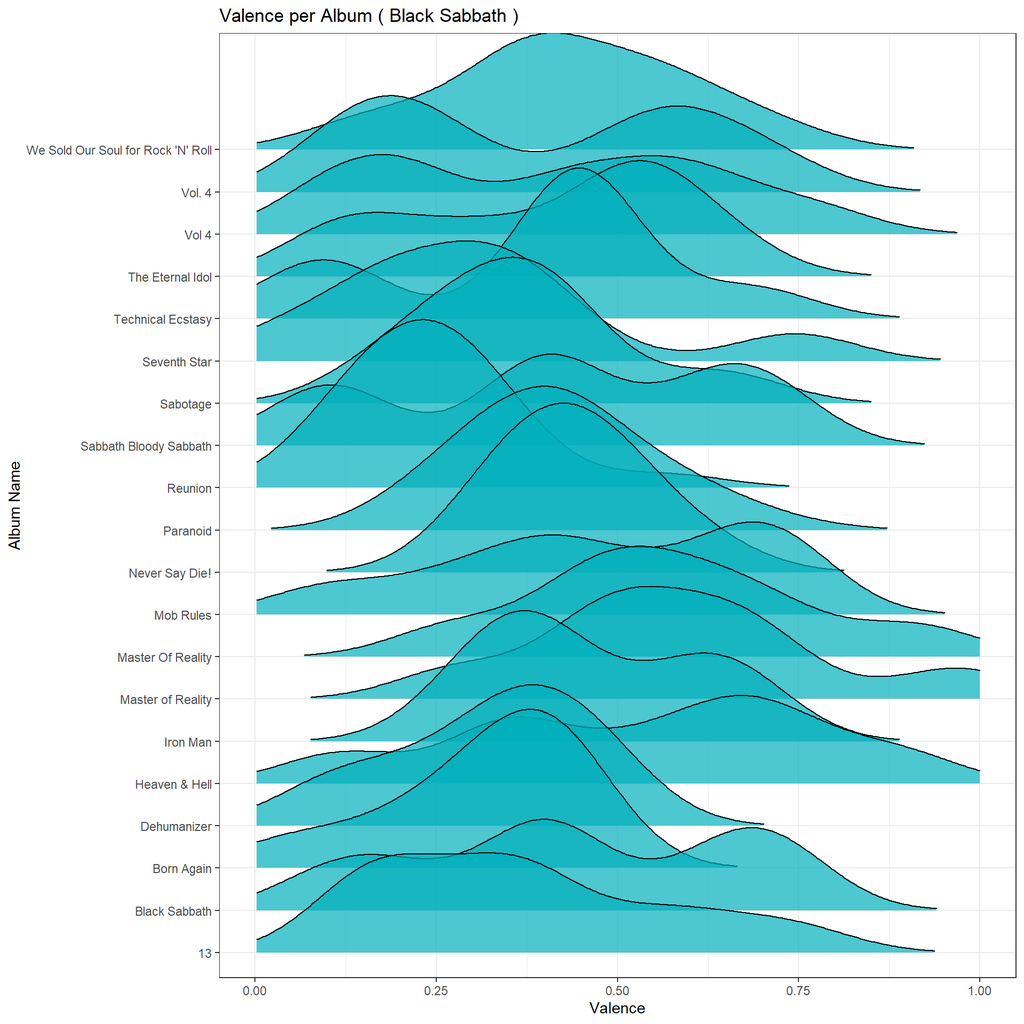

```r
plot(plot_1)
```

# Valence comparisson between multiple artist.

> Under the same thought of frame we can analyze variables such as valence or danceability for multiple artists. For this, we are going to create a formula so it is easier to enter the inputs and then get the final result.

```r
dp_multiple_artist <- function (artist1, artist2, artist3, artist4)

  {

multiple_artist <<- map_df(c(artist1, artist2, artist3, artist4), get_artist_audio_features) %>%
    mutate(label =
          case_when(stri_detect_fixed(album_name, "Collector") ~ "Duplicate",
                    stri_detect_fixed(album_name, "Remaster")  ~ "Duplicate",
                    stri_detect_fixed(album_name, "Deluxe")  ~ "Duplicate",
                    stri_detect_fixed(album_name, "deluxe")  ~ "Duplicate",
                    stri_detect_fixed(album_name, "Edition")  ~ "Duplicate",
                    stri_detect_fixed(album_name, "Remastered")  ~ "Duplicate",
                    stri_detect_fixed(album_name, "Version")  ~ "Duplicate",
                    stri_detect_fixed(album_name, "Special")  ~ "Duplicate",
                    stri_detect_fixed(album_name, "Karaoke")  ~ "Duplicate",
                    stri_detect_fixed(album_name, "Live")  ~ "Duplicate",
                    stri_detect_fixed(album_name, "Stadium")  ~ "Duplicate",
                    TRUE  ~ "Original")) %>%
  filter(label == "Original") %>%
  select(artist_name, album_name, danceability, energy, valence, track_name)

### Plot

plot1 <- ggplot(multiple_artist, aes(x = valence, y = artist_name)) +
  ylab("Artist Name") +
  xlab("Valence") +
  theme_bw() +
  geom_density_ridges(aes(fill = artist_name,
                          scale = 1.5,
                          alpha = 0.7)) +
  scale_fill_manual(values = c("#00AFBB", "#E7B800", "#FC4E07","#00e726" )) +
  theme(legend.position = "none")

plot(plot1)

}
```

## Run the function

> In this function the user has to enter the name of the artists as written in Spotify.

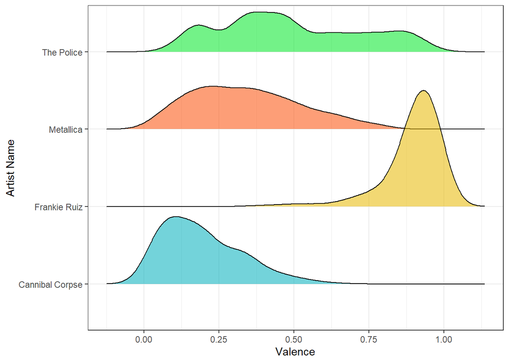

```r
dp_multiple_artist("Metallica", "Frankie Ruiz", "Cannibal Corpse", "The Police")
```

# Vibe of the music per artist

> This code pretends to show in a plot the vibe of the artist, it plots two variables, energy and valence based on the albums of a specified artist. In this case, we will take as reference Cannibal Corpse

> We take this artist to show how most of their albums are located in the upper left corner, showing high energy and low valence (low positiveness). This is a useful feature to characterize the profile of the artist.

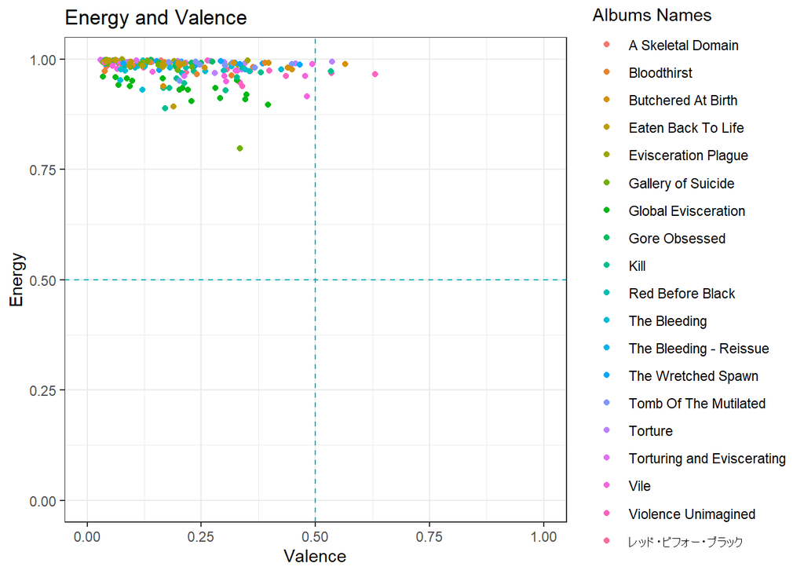

```r
## Enter the name of the artist (as is written in spotify)

artist_vibe <- get_artist_audio_features('Cannibal Corpse') %>%

## We want to exclude the albums that are  remaster, collector edition, live, karaoke and so on. This with the idea to avoid having duplicate songs that will affect the final analysis:

  mutate(label =
          case_when(stri_detect_fixed(album_name, "Collector") ~ "Duplicate",
                    stri_detect_fixed(album_name, "Remaster")  ~ "Duplicate",
                    stri_detect_fixed(album_name, "Deluxe")  ~ "Duplicate",
                    stri_detect_fixed(album_name, "deluxe")  ~ "Duplicate",
                    stri_detect_fixed(album_name, "Edition")  ~ "Duplicate",
                    stri_detect_fixed(album_name, "Remastered")  ~ "Duplicate",
                    stri_detect_fixed(album_name, "Version")  ~ "Duplicate",
                    stri_detect_fixed(album_name, "Special")  ~ "Duplicate",
                    stri_detect_fixed(album_name, "Karaoke")  ~ "Duplicate",
                    stri_detect_fixed(album_name, "Live")  ~ "Duplicate",
                    stri_detect_fixed(album_name, "Stadium")  ~ "Duplicate",
                    TRUE  ~ "Original")) %>%
  filter(label == "Original") %>%
  select(artist_name, album_name, danceability, energy, valence, track_name)

Plotscatter <- artist_vibe %>%
  ggplot(aes(x=valence, y=energy, col = album_name )) +
  ggtitle("Energy and Valence") +
  xlab("Valence") +
  ylab("Energy") +
  xlim(0, 1) +
  ylim(0, 1) +
  theme_bw() +
  geom_point() +
  geom_hline(yintercept= 0.5, linetype="dashed", color = "#00AFBB") +
  geom_vline(xintercept = 0.5, linetype="dashed", color = "#00AFBB", size=0.5)+
  guides(color = guide_legend(title = "Albums Names"))
plot(Plotscatter)
```

# Vibe of the music comparing multiple artists.

> Based on the previous analysis the code can be complemented to make comparissons between two artist or more. Here we will take as reference the multiple_artist table defined before (check the code above).

> Once again this tool helps to characterize and compare multiple artist.

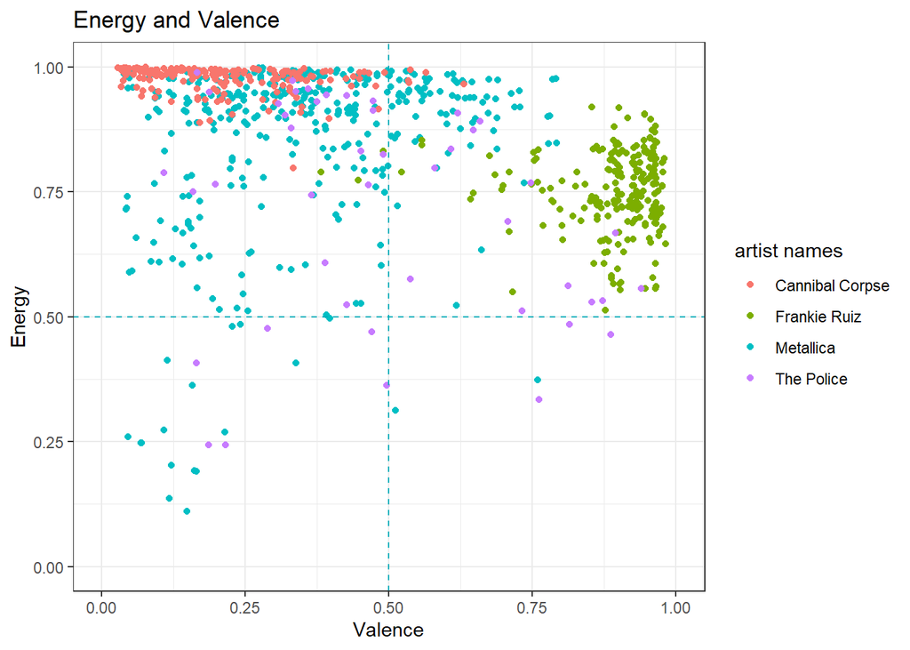

```r
Plotscatter2 <- multiple_artist %>%
  ggplot(aes(x=valence, y=energy, col = artist_name )) +
  ggtitle("Energy and Valence") +
  xlab("Valence") +
  ylab("Energy") +
  xlim(0, 1) +
  ylim(0, 1) +
  theme_bw() +
  geom_point() +
  geom_hline(yintercept= 0.5, linetype="dashed", color = "#00AFBB") +
  geom_vline(xintercept = 0.5, linetype="dashed", color = "#00AFBB", size=0.5)+
  guides(color = guide_legend(title = "artist names"))

plot(Plotscatter2)
```